# Introduction

The Data preprocessing process takes time due to the large size of the data used. Therefore, the reader can either choose to run all cell in the notebook, which will take very long and with a slower computer may result in freezing for long preiods of time.

For Project Submission 2, it is recommended to just use the Resampled Data file for quick analysis. To be able to retrieve the file and continue with analysis first run the setup libraries in section 1.1. These will show the libraries needed for the analysis and for speeding up the processes. After running the libraries, go to section 2.5 and retrieve the clean resampled data for KrakenEUR and continue the analysis.

## Setup the libraries for Notebook

```python
%load_ext watermark
%watermark

%load_ext autoreload
%autoreload 2
# import standard libs
from IPython.display import display
from IPython.core.debugger import set_trace as bp
from pathlib import PurePath, Path
import sys
import time
from collections import OrderedDict as od
import re
import os
import json
os.environ['THEANO_FLAGS'] = 'device=cpu,floatX=float32'

# import python scientific stack
import pandas as pd
pd.set_option('display.max_rows', 100)
from dask import dataframe as dd
from dask.diagnostics import ProgressBar
pbar = ProgressBar()
pbar.register()
import numpy as np
import scipy.stats as stats
import statsmodels.api as sm
from numba import jit
import math
import pymc3 as pm
from theano import shared, theano as tt

# import visual tools to make graphs pretty
import matplotlib as mpl
import matplotlib.pyplot as plt
import matplotlib.gridspec as gridspec
%matplotlib inline
import seaborn as sns

plt.style.use('seaborn-talk')
plt.style.use('bmh')

#plt.rcParams['font.family'] = 'DejaVu Sans Mono'
#plt.rcParams['font.size'] = 9.5
plt.rcParams['font.weight'] = 'medium'
#plt.rcParams['figure.figsize'] = 10,7
blue, green, red, purple, gold, teal = sns.color_palette('colorblind', 6)

# import util libs
from urllib.request import urlopen
# or: requests.get(url).content
import gzip
import datetime
import pyarrow as pa
import pyarrow.parquet as pq
from tqdm import tqdm, tqdm_notebook



# Ignore useless warnings (see SciPy issue #5998)
import warnings
warnings.filterwarnings(action="ignore", message="^internal gelsd")


#import func from py module
from bars import get_imbalance


# to make this notebook's output stable across runs
RANDOM_STATE = 777

# to get the library versions used
print()
%watermark -p pandas,dask,numba,tqdm,numpy,pymc3,theano,sklearn,statsmodels,matplotlib,seaborn,pyarrow,fastparquet
```

```
2018-11-05T15:13:01+02:00

CPython 3.6.6
IPython 7.1.1

compiler   : MSC v.1900 64 bit (AMD64)
system     : Windows
release    : 10
machine    : AMD64
processor  : Intel64 Family 6 Model 142 Stepping 9, GenuineIntel
CPU cores  : 4
interpreter: 64bit

pandas 0.23.1
dask 0.20.0
numba 0.40.0
tqdm 4.28.1
numpy 1.14.5
pymc3 3.5
theano 1.0.3
sklearn 0.19.1
statsmodels 0.9.0
matplotlib 3.0.1
seaborn 0.9.0
pyarrow 0.11.1
fastparquet 0.1.6
```

# Step 1 - Data Preprocessing

## Introduction

This notebook explores the idea of sampling prices as a function of something other than fixed time intervals. For example using the number of ticks, volume or dollar volume traded as the sampling interval. The rest of this notebook works through some of the exercises found in chapters 1 and 2 of the de Prado Book

This notebook makes use of the following script found here: `./src/features/bars.py`

## Read and Clean Data

The data used in this project covers the whole Bitcoin trades history from Bitcoincharts in CSV format here : http://api.bitcoincharts.com/v1/csv/ it is updated twice a day for active exchanges, and there is a few dead exchanges, too.

*NB*: Since there are no column headers in the CSVs, there is need to map the columns as follows: column 1) the trade's timestamp, column 2) the price, column 3) the volume of the trade (Volume (BTC)) The list of trades does not show info on market depth, the depth is an instantaneous picture of the whole two order books at a certain time while the trade sequence is just the point where the order books met.

```python
# fetch data from the bitcoincharts api, the data file is 160MB
#uncomment to download and extract automatically.

def read_crypto_ticks(fp):
    # '''read tick data from http://www.bitcoincharts.com'''
    resp = urlopen("http://api.bitcoincharts.com/v1/csv/krakenEUR.csv.gz")

    # Map the columns of the data
    cols = list(map(str.lower,['Timestamp','Price','Size']))

    # read the fetched data into pandas as a dataframe
    with gzip.open(resp) as f:
        df = (pd.read_csv(f, header=None)
          .rename(columns=dict(zip(range(len(cols)),cols)))
          .assign(dates=lambda df: (df['timestamp']).apply(lambda t:datetime.datetime.fromtimestamp(t)))
          .assign(v=lambda df: df['size']) # volume
          .assign(dv=lambda df: df['price']*df['size']) # dollar volume
          .drop(['timestamp', 'size'],axis=1)
          .set_index('dates')
          .drop_duplicates())
    return df

path = 'data/raw/'
infp = path +'krakenEUR.txt'

df_raw = read_crypto_ticks(infp)
df_raw.tail(5)
```

| dates | price | size | v | dv |
| --- | --- | --- | --- | --- |
| 2018-11-04 13:27:05 | 5562.2 | 0.143207 | 0.143207 | 796.543695 |
| 2018-11-04 13:27:05 | 5562.2 | 0.000366 | 0.000366 | 2.036655 |
| 2018-11-04 13:27:17 | 5563.6 | 0.002469 | 0.002469 | 13.738253 |
| 2018-11-04 13:27:24 | 5562.2 | 0.019014 | 0.019014 | 105.760338 |
| 2018-11-04 13:27:24 | 5563.6 | 0.041275 | 0.041275 | 229.639426 |

```python
path = 'data/'
outfp = path + 'KrakenEUR.parq'
df_raw.to_parquet(outfp)
```

## Retrieve saved Parquet file Data and Info

```python
#Optionally you can start here using the KrakenEUR.parq file, however the file is 500MB so it could not be attached"
path = 'data/'
outfp = path + 'KrakenEUR.parq'
df_int = pd.read_parquet(outfp)
df_int.head(5)
```

| dates | price | size | v | dv |
| --- | --- | --- | --- | --- |
| 2014-01-08 11:26:29 | 624.01000 | 0.20000 | 0.20000 | 124.802000 |
| 2014-01-08 11:26:38 | 624.01000 | 0.09767 | 0.09767 | 60.947057 |
| 2014-01-08 11:26:38 | 623.53836 | 0.01358 | 0.01358 | 8.467501 |
| 2014-01-08 11:27:45 | 623.53836 | 0.14896 | 0.14896 | 92.882424 |
| 2014-01-08 11:28:59 | 623.54066 | 0.20000 | 0.20000 | 124.708132 |

```python
# size was dropped to reduce file from 748 MB to 598MB
#the code was adjusted in read data accordingly
df = (df_int).drop(['size'],axis=1)
df.tail()
```

| dates | price | v | dv |
| --- | --- | --- | --- |
| 2018-11-04 13:27:05 | 5562.2 | 0.143207 | 796.543695 |
| 2018-11-04 13:27:05 | 5562.2 | 0.000366 | 2.036655 |
| 2018-11-04 13:27:17 | 5563.6 | 0.002469 | 13.738253 |
| 2018-11-04 13:27:24 | 5562.2 | 0.019014 | 105.760338 |
| 2018-11-04 13:27:24 | 5563.6 | 0.041275 | 229.639426 |

```python
df.info()
```

```
<class 'pandas.core.frame.DataFrame'>
DatetimeIndex: 19608021 entries, 2014-01-08 11:26:29 to 2018-11-04 13:27:24
Data columns (total 3 columns):
price    float64
v        float64
dv       float64
dtypes: float64(3)
memory usage: 598.4 MB
```

```python
# Data Description
df.describe()
```

|  | price | v | dv |
| --- | --- | --- | --- |
| count | 1.960802e+07 | 1.960802e+07 | 1.960802e+07 |
| mean | 4.566005e+03 | 4.724162e-01 | 1.320719e+03 |
| std | 3.638103e+03 | 1.678424e+00 | 5.513985e+03 |
| min | 1.481712e+02 | 0.000000e+00 | 0.000000e+00 |
| 25% | 1.125799e+03 | 1.612033e-02 | 4.952500e+01 |
| 50% | 3.831000e+03 | 7.090311e-02 | 1.995113e+02 |
| 75% | 7.000000e+03 | 3.000000e-01 | 7.975517e+02 |
| max | 2.000000e+04 | 4.400000e+02 | 2.310000e+06 |

## Remove Obvious Price Errors in Tick Data

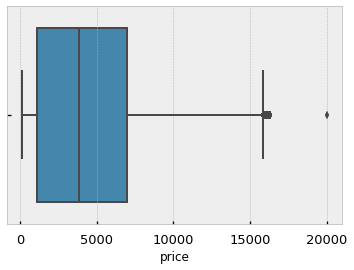

```python
sns.boxplot(df.price)
```

```python
# Median absolute deviation
# Use numba jit to speed up process
@jit(nopython=True)
def mad_outlier(y, thresh=3.):
    '''
    compute outliers based on mad
    # args
        y: assumed to be array with shape (N,1)
        thresh: float()
    # returns
        array index of outliers
    '''
    median = np.median(y)
    diff = np.sum((y - median)**2, axis=-1)
    diff = np.sqrt(diff)
    med_abs_deviation = np.median(diff)

    modified_z_score = 0.6745 * diff / med_abs_deviation

    return modified_z_score > thresh
```

```python
mad = mad_outlier(df.price.values.reshape(-1,1))
```

```python
df.loc[mad]
```

| dates | price | v | dv |
| --- | --- | --- | --- |
| 2018-01-13 13:22:39 | 20000.0 | 0.009066 | 181.3122 |
| 2018-01-13 13:22:45 | 20000.0 | 0.009194 | 183.8878 |

The 13th January price is considered an outlier and will be omitted from the data

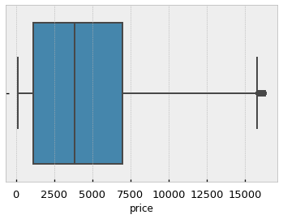

```python
sns.boxplot(df.loc[~mad].price)
```

Drop outliers from dataset and save cleaned data in the `./data/` folder.

```python
#Drop outliers
df_clean = df.loc[~mad]
df_clean.tail(5)
```

| dates | price | v | dv |
| --- | --- | --- | --- |
| 2018-11-04 13:27:05 | 5562.2 | 0.143207 | 796.543695 |
| 2018-11-04 13:27:05 | 5562.2 | 0.000366 | 2.036655 |
| 2018-11-04 13:27:17 | 5563.6 | 0.002469 | 13.738253 |
| 2018-11-04 13:27:24 | 5562.2 | 0.019014 | 105.760338 |
| 2018-11-04 13:27:24 | 5563.6 | 0.041275 | 229.639426 |

```python
# Save the processed data
cleanfp = path + 'clean_KrakenEUR.parq'
df_clean.to_parquet(cleanfp)
```

## Retrieve cleaned Parquet file Data

```python
#Optionally you can start here using the clean_KrakenEUR.parq file, the file is 385 MB
path = 'data/'
outfp = path + 'clean_KrakenEUR.parq'
df_clean = pd.read_parquet(outfp)
df_clean.head(5)
```

| dates | price | v | dv |
| --- | --- | --- | --- |
| 2014-01-08 11:26:29 | 624.01000 | 0.20000 | 124.802000 |
| 2014-01-08 11:26:38 | 624.01000 | 0.09767 | 60.947057 |
| 2014-01-08 11:26:38 | 623.53836 | 0.01358 | 8.467501 |
| 2014-01-08 11:27:45 | 623.53836 | 0.14896 | 92.882424 |
| 2014-01-08 11:28:59 | 623.54066 | 0.20000 | 124.708132 |

# Data Resampled to 15 Min intervals

Resampling involves changing the frequency of your time series observations. Two types of resampling are: Upsampling: Where you increase the frequency of the samples, such as from minutes to seconds. Downsampling: Where you decrease the frequency of the samples, such as from days to months.

The resample() function in Pandas will group all observations by the new frequency. We could use an alias like “15Min” to create groups of (EOD) data. Pandas does have a time-aware alias of “15Min” that we can use for this purpose. We must now decide how to create a new end of day value from each group of seconds data. A good starting point is to calculate the average daily price numbers. For this, we can use the mean() function.

```python
df_clean.info()
```

```
<class 'pandas.core.frame.DataFrame'>
DatetimeIndex: 19608019 entries, 2014-01-08 11:26:29 to 2018-11-04 13:27:24
Data columns (total 3 columns):
price    float64
v        float64
dv       float64
dtypes: float64(3)
memory usage: 598.4 MB
```

```python
# Resample data to end of day
df_EOD = pd.DataFrame()
df_EOD['price'] = df_clean.price.resample('15Min').mean()
df_EOD['v'] = df_clean.v.resample('15Min').sum()
df_EOD['vcumsum'] = (df_clean.v.cumsum()).resample('15Min').last()
df_EOD['dv'] = df_clean.dv.resample('15Min').sum()
df_EOD['dvcumsum'] = (df_clean.dv.cumsum()).resample('15Min').last()
df_EOD.head()
```

| dates | price | v | vcumsum | dv | dvcumsum |
| --- | --- | --- | --- | --- | --- |
| 2014-01-08 11:15:00 | 623.727476 | 0.660210 | 0.660210 | 411.807114 | 411.807114 |
| 2014-01-08 11:30:00 | 625.757599 | 7.999921 | 8.660131 | 5002.228467 | 5414.035581 |
| 2014-01-08 11:45:00 | 628.710288 | 7.736938 | 16.397068 | 4862.615486 | 10276.651067 |
| 2014-01-08 12:00:00 | 623.550000 | 0.011480 | 16.408548 | 7.158354 | 10283.809421 |
| 2014-01-08 12:15:00 | 631.936829 | 7.807750 | 24.216298 | 4933.959300 | 15217.768720 |

```python
df_EOD.info()
```

```
<class 'pandas.core.frame.DataFrame'>
DatetimeIndex: 169065 entries, 2014-01-08 11:15:00 to 2018-11-04 13:15:00
Freq: 15T
Data columns (total 5 columns):
price       160638 non-null float64
v           169065 non-null float64
vcumsum     169065 non-null float64
dv          169065 non-null float64
dvcumsum    169065 non-null float64
dtypes: float64(5)
memory usage: 7.7 MB
```

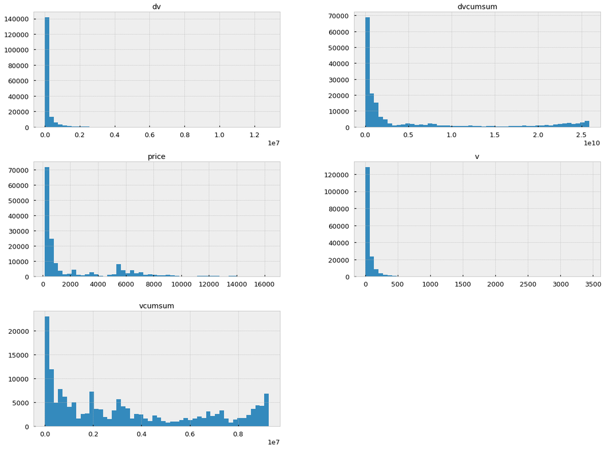

```python
#visualize
df_EOD.hist(bins=50, figsize=(20,15))
plt.show()
```

```python
df_EOD.describe()
```

|  | price | v | vcumsum | dv | dvcumsum |
| --- | --- | --- | --- | --- | --- |
| count | 160638.000000 | 169065.000000 | 1.690650e+05 | 1.690650e+05 | 1.690650e+05 |
| mean | 2190.872381 | 54.790450 | 3.443919e+06 | 1.531759e+05 | 5.100983e+09 |
| std | 2982.657332 | 91.949232 | 3.107626e+06 | 3.831328e+05 | 8.118093e+09 |
| min | 150.374575 | 0.000000 | 6.602100e-01 | 0.000000e+00 | 4.118071e+02 |
| 25% | 319.880593 | 5.947908 | 6.284850e+05 | 2.453970e+03 | 1.869902e+08 |
| 50% | 545.949995 | 24.291691 | 2.486193e+06 | 1.594233e+04 | 7.806212e+08 |
| 75% | 3531.130348 | 65.859260 | 6.362083e+06 | 1.225141e+05 | 6.179861e+09 |
| max | 16308.470917 | 3440.602076 | 9.263147e+06 | 1.282847e+07 | 2.589669e+10 |

```python
# Save the processed data
Kraken15T = path + '15T_KrakenEUR.parq'
df_EOD.to_parquet(Kraken15T)
```

# Submission 1 Tasks

## Retrieve saved Resampled Data

```python
#Optionally you can start here using the 15T_KrakenEUR.parq file, the file is 9 MB"
path = 'data/'
outfp = path + '15T_KrakenEUR.parq'
df_EOD = pd.read_parquet(outfp)
df_EOD.head(5)
```

| dates | price | v | vcumsum | dv | dvcumsum |
| --- | --- | --- | --- | --- | --- |
| 2014-01-08 11:15:00 | 623.727476 | 0.660210 | 0.660210 | 411.807114 | 411.807114 |
| 2014-01-08 11:30:00 | 625.757599 | 7.999921 | 8.660131 | 5002.228467 | 5414.035581 |
| 2014-01-08 11:45:00 | 628.710288 | 7.736938 | 16.397068 | 4862.615486 | 10276.651067 |
| 2014-01-08 12:00:00 | 623.550000 | 0.011480 | 16.408548 | 7.158354 | 10283.809421 |
| 2014-01-08 12:15:00 | 631.936829 | 7.807750 | 24.216298 | 4933.959300 | 15217.768720 |

## Tick Bars

```python
# tqdm is used to speed up the process
def tick_bars(df, price_column, m):
    '''
    compute tick bars

    # args
        df: pd.DataFrame()
        column: name for price data
        m: int(), threshold value for ticks
    # returns
        idx: list of indices
    '''
    t = df[price_column]
    ts = 0
    idx = []
    '''tqdm is used because its overhead is low.
    tqdm uses smart algorithms to predict the remaining time and
    to skip unnecessary iteration displays
    '''
    for i, x in enumerate(tqdm(t)):
        ts += 1
        if ts >= m:
            idx.append(i)
            ts = 0
            continue
    return idx

def tick_bar_df(df, price_column, m):
    idx = tick_bars(df, price_column, m)
    return df.iloc[idx].drop_duplicates()
```

There are many ways to choose `M`, or the threshold value for sampling prices. One way is based on ratios of total dollar value/volume traded vs number of ticks. The rest of the notebook uses an arbitrary but sensible `M` value calculated from len(df)/10000

```python
tick_M = 17   # M = len(df)/10000
print("tick thres hold: %d" % (tick_M))
tidx = tick_bars(df_EOD, 'price', tick_M)
tidx[:10]
```

```
tick thres hold: 17
```

```
[16, 33, 50, 67, 84, 101, 118, 135, 152, 169]
```

```python
df_EOD.iloc[tidx].shape, df_EOD.shape
```

```
((9945, 5), (169065, 5))
```

Dataset is large so select smaller example for quick exploration

```python
tick_df = tick_bar_df(df_EOD, 'price', tick_M)
tick_df.shape
```

```
(9648, 5)
```

```python
df_EOD[9648:].head() #get valid date index
```

| dates | price | v | vcumsum | dv | dvcumsum |
| --- | --- | --- | --- | --- | --- |
| 2014-04-18 23:15:00 | 352.874628 | 0.932186 | 75150.423778 | 329.021657 | 3.218468e+07 |
| 2014-04-18 23:30:00 | 352.761680 | 1.244781 | 75151.668559 | 439.197474 | 3.218512e+07 |
| 2014-04-18 23:45:00 | 351.222040 | 0.222153 | 75151.890712 | 78.031898 | 3.218520e+07 |
| 2014-04-19 00:00:00 | 352.062580 | 0.077342 | 75151.968054 | 27.229097 | 3.218522e+07 |
| 2014-04-19 00:15:00 | 352.062580 | 1.000000 | 75152.968054 | 352.062580 | 3.218558e+07 |

```python
def select_sample_data(ref, sub, price_col, date):
    '''
    select a sample of data based on date, assumes datetimeindex

    # args
        ref: pd.DataFrame containing all ticks
        sub: subordinated pd.DataFrame of prices
        price_col: str(), price column
        date: str(), date to select
    # returns
        xdf: ref pd.Series
        xtdf: subordinated pd.Series
    '''
    xdf = ref[price_col].loc[date]
    xtdf = sub[price_col].loc[date]
    return xdf, xtdf

## try different dates to see how the quantity of tick bars changes
xDate ='2014-01-18' #'use date in df.head()
xdf, xtdf = select_sample_data(df_EOD, tick_df, 'price', xDate)

xdf.shape, xtdf.shape
```

```
((96,), (6,))
```

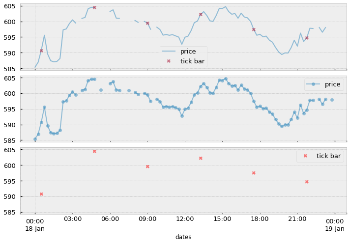

```python
def plot_sample_data(ref, sub, bar_type, *args, **kwds):
    f,axes=plt.subplots(3,sharex=True, sharey=True, figsize=(10,7))
    ref.plot(*args, **kwds, ax=axes[0], label='price')
    sub.plot(*args, **kwds, ax=axes[0], marker='X', ls='', label=bar_type)
    axes[0].legend();

    ref.plot(*args, **kwds, ax=axes[1], label='price', marker='o')
    sub.plot(*args, **kwds, ax=axes[2], ls='', marker='X',
             color='r', label=bar_type)

    for ax in axes[1:]: ax.legend()
    plt.tight_layout()

    return

plot_sample_data(xdf, xtdf, 'tick bar', alpha=0.5, markersize=7)
```

### Make OHLC Bars from Custom Bars

Extract `tick_df.price` and `df.price` into two pandas series.

```python
sub = tick_df.price
ref = df_EOD.price
```

The function below creates the OHLC dataframe by:

```
1. Iterating over the subordinated series' index extracting idx and idx+1 period
2. Selecting the same date period from the reference series
3. Extracting the max, min prices from the reference series.
4. Combining the o,h,l,c and start and end timestamps into a row
5. Returning the aggregated rows as a pandas dataframe.
```

```python
def get_ohlc(ref, sub):
    '''
    fn: get ohlc from custom bars

    # args
        ref : reference pandas series with all prices
        sub : custom tick pandas series
    # returns
        tick_df : dataframe with ohlc values
    '''
    ohlc = []
    for i in tqdm(range(sub.index.shape[0]-1)):
        start,end = sub.index[i], sub.index[i+1]
        tmp_ref = ref.loc[start:end]
        max_px, min_px = tmp_ref.max(), tmp_ref.min()
        o,h,l,c = sub.iloc[i], max_px, min_px, sub.iloc[i+1]
        ohlc.append((end,start,o,h,l,c))
    cols = ['end','start','open','high','low','close']
    df = pd.DataFrame(ohlc,columns=cols)
    return df

## It takes about 5-6 mins on my machine)
tick_bars_ohlc = get_ohlc(ref, sub)


outf2 = path + 'tick_bars_ohlc.parq'
tick_bars_ohlc.to_parquet(outf2)
tick_bars_ohlc.head(5)
```

|  | end | start | open | high | low | close |
| --- | --- | --- | --- | --- | --- | --- |
| 0 | 2014-01-08 19:30:00 | 2014-01-08 15:15:00 | 627.354802 | 627.354802 | 604.220675 | 615.536394 |
| 1 | 2014-01-08 23:45:00 | 2014-01-08 19:30:00 | 615.536394 | 617.921253 | 607.711826 | 611.604286 |
| 2 | 2014-01-09 04:00:00 | 2014-01-08 23:45:00 | 611.604286 | 618.515965 | 606.752000 | 615.165520 |
| 3 | 2014-01-09 08:15:00 | 2014-01-09 04:00:00 | 615.165520 | 624.908397 | 612.305745 | 614.849593 |
| 4 | 2014-01-09 12:30:00 | 2014-01-09 08:15:00 | 614.849593 | 625.991219 | 614.849593 | 623.270514 |

## Volume Bars

```python
def volume_bars(df, volume_column, m):
    '''
    compute volume bars

    # args
        df: pd.DataFrame()
        volume_column: name for volume data
        m: int(), threshold value for volume
    # returns
        idx: list of indices
    '''
    t = df[volume_column]
    ts = 0
    idx = []
    for i, x in enumerate(tqdm(t)):
        ts += x
        if ts >= m:
            idx.append(i)
            ts = 0
            continue
    return idx

def volume_bar_df(df, volume_column, m):
    idx = volume_bars(df, volume_column, m)
    return df.iloc[idx].drop_duplicates()
```

```python
df_EOD['vcumsum'][-1:] # value
```

```
dates
2018-11-04 13:15:00    9.263147e+06
Name: vcumsum, dtype: float64
```

```python
volume_M =  9260 #  # M = len(df)/1000
print('volume threshold: %d' % (volume_M))
v_bar_df = volume_bar_df(df_EOD, 'vcumsum', volume_M)


## Extract close price
sub = v_bar_df.price
v_bars_ohlc = get_ohlc(ref, sub)



#save the file
outf2 = path + 'v_bars_ohlc.parq'
v_bars_ohlc.to_parquet(outf2)

v_bars_ohlc.head(5)
```

```
volume threshold: 9260
```

|  | end | start | open | high | low | close |
| --- | --- | --- | --- | --- | --- | --- |
| 0 | 2014-01-09 07:45:00 | 2014-01-09 01:00:00 | 606.752000 | 624.908397 | 606.752000 | NaN |
| 1 | 2014-01-09 13:30:00 | 2014-01-09 07:45:00 | NaN | 625.991219 | 612.305745 | 616.563594 |
| 2 | 2014-01-09 17:45:00 | 2014-01-09 13:30:00 | 616.563594 | 621.184855 | 597.389914 | 604.829386 |
| 3 | 2014-01-09 21:15:00 | 2014-01-09 17:45:00 | 604.829386 | 611.342857 | 597.584891 | 602.601659 |
| 4 | 2014-01-10 00:15:00 | 2014-01-09 21:15:00 | 602.601659 | 619.582176 | 602.601659 | 619.582176 |

```python
v_bar_df.shape # to get valid dates within index
```

```
(161336, 5)
```

```python
df_EOD[161336:].head() #get valid date index
```

| dates | price | v | vcumsum | dv | dvcumsum |
| --- | --- | --- | --- | --- | --- |
| 2018-08-16 01:15:00 | 5538.995972 | 113.786060 | 9.042571e+06 | 630648.798232 | 2.465212e+10 |
| 2018-08-16 01:30:00 | 5526.151309 | 55.021840 | 9.042626e+06 | 304414.734955 | 2.465243e+10 |
| 2018-08-16 01:45:00 | 5531.450769 | 12.711296 | 9.042639e+06 | 70298.685823 | 2.465250e+10 |
| 2018-08-16 02:00:00 | 5509.667105 | 71.234677 | 9.042710e+06 | 392208.267249 | 2.465289e+10 |
| 2018-08-16 02:15:00 | 5519.065753 | 10.659475 | 9.042720e+06 | 58830.213564 | 2.465295e+10 |

```
xdf shape: 96
xtdf shape: 96
```

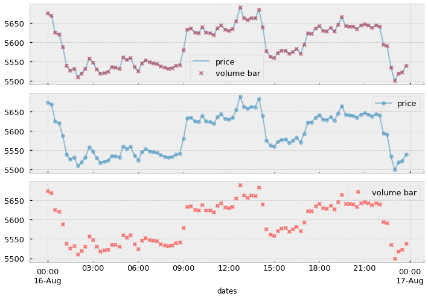

```python
xDate = '2018-08-16'
xdf, xtdf = select_sample_data(df_EOD, v_bar_df, 'price', xDate)
print('xdf shape: %d' %(xdf.shape))
print('xtdf shape: %d' %(xtdf.shape))
plot_sample_data(xdf, xtdf, 'volume bar', alpha=0.5, markersize=7)
```

## Dollar Value Bars

```python
def dollar_bars(df, dv_column, m):
    '''
    compute dollar bars

    # args
        df: pd.DataFrame()
        dv_column: name for dollar volume data
        m: int(), threshold value for dollars
    # returns
        idx: list of indices
    '''
    t = df[dv_column]
    ts = 0
    idx = []
    for i, x in enumerate(tqdm(t)):
        ts += x
        if ts >= m:
            idx.append(i)
            ts = 0
            continue
    return idx

def dollar_bar_df(df, dv_column, m):
    idx = dollar_bars(df, dv_column, m)
    return df.iloc[idx].drop_duplicates()
```

```python
df_EOD['dvcumsum'][-1:] # value
```

```
dates
2018-11-04 13:15:00    2.589669e+10
Name: dvcumsum, dtype: float64
```

```python
dollar_M = 2589 # M = dollar/10,000,000 "Since its a product of Price & Volume"
print('dollar threshold: %d' % (dollar_M))
dv_bar_df = dollar_bar_df(df_EOD, 'dvcumsum', dollar_M)

## Extract the closing price using ohlc
sub = dv_bar_df.price
dv_bars_ohlc = get_ohlc(ref, sub)

#save the file
outf2 = path + 'dv_bars_ohlc.parq'
dv_bars_ohlc.to_parquet(outf2)

dv_bars_ohlc.head(5)
```

```
dollar threshold: 2589
```

|  | end | start | open | high | low | close |
| --- | --- | --- | --- | --- | --- | --- |
| 0 | 2014-01-08 11:45:00 | 2014-01-08 11:30:00 | 625.757599 | 628.710288 | 625.757599 | 628.710288 |
| 1 | 2014-01-08 12:00:00 | 2014-01-08 11:45:00 | 628.710288 | 628.710288 | 623.550000 | 623.550000 |
| 2 | 2014-01-08 12:15:00 | 2014-01-08 12:00:00 | 623.550000 | 631.936829 | 623.550000 | 631.936829 |
| 3 | 2014-01-08 12:30:00 | 2014-01-08 12:15:00 | 631.936829 | 634.640600 | 631.936829 | 634.640600 |
| 4 | 2014-01-08 12:45:00 | 2014-01-08 12:30:00 | 634.640600 | 634.640600 | 633.701593 | 633.701593 |

```python
dv_bar_df.shape # to get valid dates within index
```

```
(162946, 5)
```

```python
df_EOD[162949:].head() #get valid date index
```

| dates | price | v | vcumsum | dv | dvcumsum |
| --- | --- | --- | --- | --- | --- |
| 2018-09-01 20:30:00 | 6171.620988 | 6.525587 | 9.098698e+06 | 40271.629371 | 2.497477e+10 |
| 2018-09-01 20:45:00 | 6172.754955 | 12.314632 | 9.098710e+06 | 76030.817214 | 2.497484e+10 |
| 2018-09-01 21:00:00 | 6187.307018 | 44.263011 | 9.098755e+06 | 273934.648575 | 2.497512e+10 |
| 2018-09-01 21:15:00 | 6205.876106 | 64.153434 | 9.098819e+06 | 398368.045300 | 2.497551e+10 |
| 2018-09-01 21:30:00 | 6207.661017 | 23.693280 | 9.098843e+06 | 147097.207067 | 2.497566e+10 |

```
xdf shape: 96
xtdf shape: 96
```

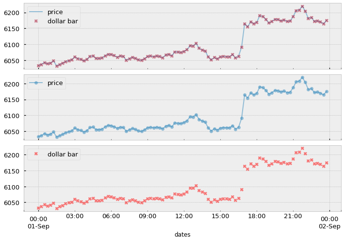

```python
xDate = '2018-09-01'  #use the table above to get correct date
xdf, xtdf = select_sample_data(df_EOD, dv_bar_df, 'price', xDate)
print('xdf shape: %d' %(xdf.shape))
print('xtdf shape: %d' %(xtdf.shape))
plot_sample_data(xdf, xtdf, 'dollar bar', alpha=0.5, markersize=7)
```

## Time Bars

```python
def time_bars(df, time_column, m):
    '''
    compute dollar bars

    # args
        df: pd.DataFrame()
        dv_column: name for cumsum price data
        m: int(), threshold value for pcumsum
    # returns
        idx: list of indices
    '''
    t = df[time_column]
    ts = 0
    idx = []
    for i, x in enumerate(tqdm(t)):
        ts += x
        if ts >= m:
            idx.append(i)
            ts = 0
            continue
    return idx

def time_bar_df(df, time_column, m):
    idx = time_bars(df, time_column, m)
    return df.iloc[idx].drop_duplicates()
```

```python
df_EOD.tail()
```

| dates | price | v | vcumsum | dv | dvcumsum |
| --- | --- | --- | --- | --- | --- |
| 2018-11-04 12:15:00 | 5554.349485 | 27.282145 | 9.263041e+06 | 151549.727065 | 2.589609e+10 |
| 2018-11-04 12:30:00 | 5550.259140 | 33.171635 | 9.263074e+06 | 183773.031447 | 2.589628e+10 |
| 2018-11-04 12:45:00 | 5554.623810 | 26.312567 | 9.263100e+06 | 146161.684645 | 2.589642e+10 |
| 2018-11-04 13:00:00 | 5556.984553 | 27.402871 | 9.263128e+06 | 152233.907347 | 2.589658e+10 |
| 2018-11-04 13:15:00 | 5561.541270 | 19.658408 | 9.263147e+06 | 109336.659583 | 2.589669e+10 |

```python
time_M = 350  # M = len(df)/1000,000
print("time thres hold: %d" % (time_M))
time_df = time_bar_df(df_EOD, 'price', time_M)

## Extract the closing price using ohlc

sub = time_df.price
ref = df_EOD
time_ohlc = get_ohlc(ref, sub)
time_ohlc.head(5)
```

```
time thres hold: 350
```

|  | end | start | open | high | low | close |
| --- | --- | --- | --- | --- | --- | --- |
| 0 | 2014-01-08 11:30:00 | 2014-01-08 11:15:00 | 623.727476 | price 625.757599 v 7.99992... | price 623.727476 v 0.660210 ... | 625.757599 |
| 1 | 2014-01-08 11:45:00 | 2014-01-08 11:30:00 | 625.757599 | price 628.710288 v 7.999... | price 625.757599 v 7.73693... | 628.710288 |
| 2 | 2014-01-08 12:00:00 | 2014-01-08 11:45:00 | 628.710288 | price 628.710288 v 7.736... | price 623.550000 v 0.011... | 623.550000 |
| 3 | 2014-01-08 12:15:00 | 2014-01-08 12:00:00 | 623.550000 | price 631.936829 v 7.807... | price 623.550000 v 0.011... | 631.936829 |
| 4 | 2014-01-08 12:30:00 | 2014-01-08 12:15:00 | 631.936829 | price 634.640600 v 7.807... | price 631.936829 v 4.569... | 634.640600 |

```python
time_df.shape # to get valid dates within index
```

```
(58, 5)
```

```python
df_EOD[58:].head() #get valid date index
```

| dates | price | v | vcumsum | dv | dvcumsum |
| --- | --- | --- | --- | --- | --- |
| 2014-01-09 01:45:00 | NaN | 0.000000 | 315.891038 | 0.000000 | 195313.141058 |
| 2014-01-09 02:00:00 | 617.771923 | 14.665304 | 330.556343 | 9078.725555 | 204391.866613 |
| 2014-01-09 02:15:00 | 617.242207 | 2.412433 | 332.968775 | 1494.360547 | 205886.227160 |
| 2014-01-09 02:30:00 | 613.003681 | 4.653594 | 337.622369 | 2846.621849 | 208732.849009 |
| 2014-01-09 02:45:00 | 614.306943 | 0.254697 | 337.877066 | 156.572320 | 208889.421329 |

```
xdf shape: 96
xtdf shape: 7
```

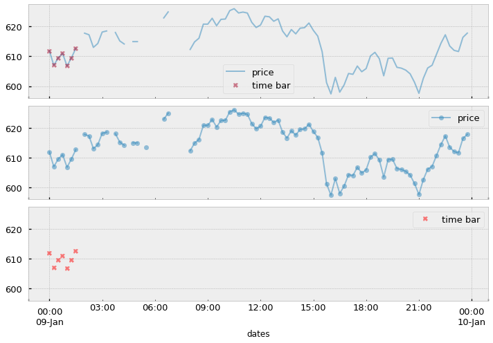

```python
xDate = '2014-01-09'  #use the table above to get correct date
xdf, xtdf = select_sample_data(df_EOD, time_df, 'price', xDate)
print('xdf shape: %d' %(xdf.shape))
print('xtdf shape: %d' %(xtdf.shape))
plot_sample_data(xdf, xtdf, 'time bar', alpha=0.5, markersize=7)
```

```python
time_ohlc.head()
```

|  | end | start | open | high | low | close |
| --- | --- | --- | --- | --- | --- | --- |
| 0 | 2014-01-08 11:30:00 | 2014-01-08 11:15:00 | 623.727476 | price 625.757599 v 7.99992... | price 623.727476 v 0.660210 ... | 625.757599 |
| 1 | 2014-01-08 11:45:00 | 2014-01-08 11:30:00 | 625.757599 | price 628.710288 v 7.999... | price 625.757599 v 7.73693... | 628.710288 |
| 2 | 2014-01-08 12:00:00 | 2014-01-08 11:45:00 | 628.710288 | price 628.710288 v 7.736... | price 623.550000 v 0.011... | 623.550000 |
| 3 | 2014-01-08 12:15:00 | 2014-01-08 12:00:00 | 623.550000 | price 631.936829 v 7.807... | price 623.550000 v 0.011... | 631.936829 |
| 4 | 2014-01-08 12:30:00 | 2014-01-08 12:15:00 | 631.936829 | price 634.640600 v 7.807... | price 631.936829 v 4.569... | 634.640600 |

# Analyzing the Bars

## Count Quantity of Bars By Each Bar Type (Weekly)

```python
def count_bars(df, price_col='price'):
    df.index = pd.to_datetime(df.index)
    return df[price_col].resample('W', label='right').count()

def scale(s):
    return (s-s.min())/(s.max()-s.min())
```

```python
# count close price series
# scale to compare 'apples to apples'
tc = scale(count_bars(tick_df))
vc = scale(count_bars(v_bar_df))
dc = scale(count_bars(dv_bar_df))
dfc = scale(count_bars(time_df))

#count_df = pd.concat([dfc, tc, vc, dc], axis=1)
#count_df.columns = ['time', 'tick', 'volume', 'dollar']
```

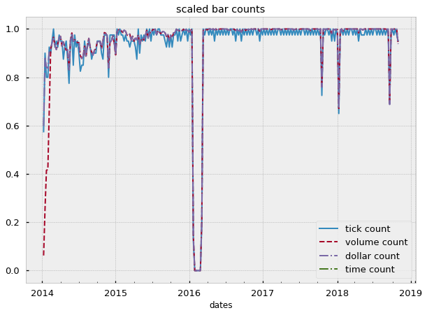

```python
# plot time series of count

f,ax=plt.subplots(figsize=(10,7))

tc.plot(ax=ax, ls='-', label='tick count')
vc.plot(ax=ax, ls='--', label='volume count')
dc.plot(ax=ax, ls='-.', label='dollar count')
dfc.plot(ax=ax, ls='-.', label='time count')
ax.set_title('scaled bar counts')
ax.legend()
```

## Which Bar Type Has Most Stable Counts?

```python
print( 'tc std : %.2f, vc std : %.2f, dc std : %.2f, dfc std : %.2f' %(tc.std(), + vc.std(), + dc.std(), + dfc.std()))

bar_types = ['tick','volume','dollar','time']
bar_std = [tc.std(),vc.std(),dc.std(),dfc.std()]
counts = (pd.Series(bar_std,index=bar_types))
counts.sort_values()
```

```
tc std : 0.16, vc std : 0.18, dc std : 0.16, dfc std : nan
```

```
dollar    0.160927
tick      0.161317
volume    0.181194
time           NaN
dtype: float64
```

## Which Bar Type Has the Lowest Serial Correlation?

```python
def partition_aly(s):
    return s.resample('1M').var()
```

```python
def returns(s):
    arr = np.diff(np.log(s))
    return (pd.Series(arr, index=s.index[1:]))
```

```python
tr = returns(tick_df.price).dropna()
vr = returns(v_bar_df.price).dropna()
dr = returns(dv_bar_df.price).dropna()
df_ret = returns(time_df.price).dropna()

bar_returns = [tr, vr, dr, df_ret]
```

```python
def get_test_stats(bar_types,bar_returns,test_func,*args,**kwds):

    dct = {bar:(int(bar_ret.shape[0]), test_func(bar_ret,*args,**kwds))
           for bar,bar_ret in zip(bar_types,bar_returns)}
    df = (pd.DataFrame.from_dict(dct)
          .rename(index={0:'sample_size',1:str('%s' %(test_func).__name__)+'_stat'})
          .T)

    return df
```

```python
autocorrs = get_test_stats(bar_types,bar_returns,pd.Series.autocorr)
autocorrs
```

|  | sample_size | autocorr_stat |
| --- | --- | --- |
| tick | 9261.0 | -0.042239 |
| volume | 156927.0 | 0.168106 |
| dollar | 158327.0 | 0.168577 |
| time | 57.0 | -0.096885 |

```python
display(autocorrs.sort_values('autocorr_stat'),
        autocorrs.abs().sort_values('autocorr_stat'))
```

|  | sample_size | autocorr_stat |
| --- | --- | --- |
| time | 57.0 | -0.096885 |
| tick | 9261.0 | -0.042239 |
| volume | 156927.0 | 0.168106 |
| dollar | 158327.0 | 0.168577 |

|  | sample_size | autocorr_stat |
| --- | --- | --- |
| tick | 9261.0 | 0.042239 |
| time | 57.0 | 0.096885 |
| volume | 156927.0 | 0.168106 |
| dollar | 158327.0 | 0.168577 |

```python
def plot_autocorr(bar_types,bar_returns):
    f,axes=plt.subplots(len(bar_types),figsize=(10,7))

    for i, (bar, typ) in enumerate(zip(bar_returns, bar_types)):
        sm.graphics.tsa.plot_acf(bar, lags=20, ax=axes[i],
                                 alpha=0.05, unbiased=True, fft=True,
                                 zero=False,
                                 title='%s'%(typ)+''+ 'AutoCorr')
    plt.tight_layout()

def plot_hist(bar_types,bar_rets):
    f,axes=plt.subplots(len(bar_types),figsize=(10,6))
    for i, (bar, typ) in enumerate(zip(bar_returns, bar_types)):
        g = sns.distplot(bar, ax=axes[i], kde=False, label=typ)
        g.set(yscale='log')
        axes[i].legend()
    plt.tight_layout()
```

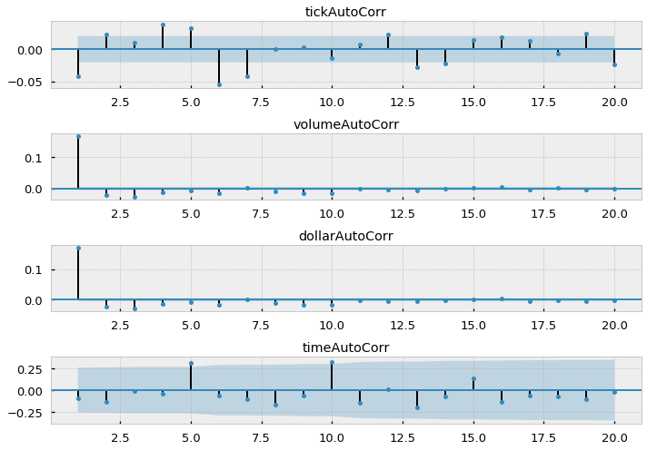

```python
 plot_autocorr(bar_types,bar_returns)
```

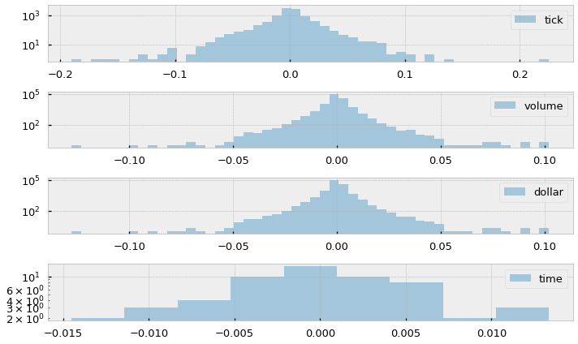

```python
plot_hist(bar_types,bar_returns)
```

## Partition Bar Series into Monthly, Compute Variance of Returns, and Variance of Variance

```python
def partition_monthly(s):
    return s.resample('1M').var()
```

```python
tr_rs = partition_monthly(tr)
vr_rs = partition_monthly(vr)
dr_rs = partition_monthly(dr)
df_ret_rs = partition_monthly(df_ret)
monthly_vars = [tr_rs, vr_rs, dr_rs, df_ret_rs]
```

```python
get_test_stats(bar_types,monthly_vars,np.var).sort_values('var_stat')
```

|  | sample_size | var_stat |
| --- | --- | --- |
| time | 1.0 | 0.000000e+00 |
| dollar | 59.0 | 2.260620e-10 |
| volume | 59.0 | 2.403356e-10 |
| tick | 59.0 | 8.966386e-08 |

## Compute Jarque-Bera Test, Which Has Lowest Test Statistic?

```python
def jb(x,test=True):
    np.random.seed(12345678)
    if test: return stats.jarque_bera(x)[0]
    return stats.jarque_bera(x)[1]

get_test_stats(bar_types,bar_returns,jb).sort_values('jb_stat')
```

|  | sample_size | jb_stat |
| --- | --- | --- |
| time | 57.0 | 1.727469e-01 |
| tick | 9261.0 | 9.601526e+04 |
| dollar | 158327.0 | 1.595136e+07 |
| volume | 156927.0 | 1.597597e+07 |

## Compute Shapiro-Wilk Test

Shapiro-Wilk test statistic > larger is better.

```python
def shapiro(x,test=True):
    np.random.seed(42)
    if test: return stats.shapiro(x)[0]
    return stats.shapiro(x)[1]

(get_test_stats(bar_types,bar_returns,shapiro)
 .sort_values('shapiro_stat')[::-1])
```

|  | sample_size | shapiro_stat |
| --- | --- | --- |
| time | 57.0 | 0.991569 |
| tick | 9261.0 | 0.835704 |
| dollar | 158327.0 | 0.782454 |
| volume | 156927.0 | 0.780654 |

# Compare Serial Correlation between Dollar and Dollar Imbalance Bars

### Get Dollar Imbalance Bars

Earlier version was missing some additional code. Before we can compare we must compute the Dollar Imbalance Bar. This is my initial implementation of this concept but is experimental and may need some adjustments.

1. Compute the sequence ${bt}_{t=1,...,T}$.
2. Compute the imbalance at time $T$ defined as $\theta_T = \sum_{t=1}^{T}b_tv_t$.
3. Compute the expected value of $T$ as ewma of previous $T$ values.
4. Compute the expected value of $\theta_T$ as ewma of $b_tv_t$ values.
5. for each index:
   - compute $\lvert\theta_t\rvert >= E_0[T] * \lvert2v^+-E_0[v_t]\rvert$
   - if the condition is met capture the quantity of ticks
   - reset tick count
   - continue

```python
# Get the dollar imbalance formula from bars.py module# Compute the time index for dollar imbalance
# Compute the time index for dollar imbalance
tidx = get_imbalance(df_EOD.price.values)*df_EOD.dv.iloc[1:]
tidx.head()
```

```
dates
2014-01-08 11:30:00    5002.228467
2014-01-08 11:45:00    4862.615486
2014-01-08 12:00:00      -7.158354
2014-01-08 12:15:00    4933.959300
2014-01-08 12:30:00    2899.684645
Name: dv, dtype: float64
```

```python
wndo = tidx.shape[0]//1000
print('window size: %.2f' % (wndo))

## Expected value of bs approximated by ewm
E_bs = tidx.ewm(wndo).mean() # expected `bs`

## what is E_T???
## in this implementation E_T is ewm of index values
E_T = pd.Series(range(tidx.shape[0]), index=tidx.index).ewm(wndo).mean()

df0 =(pd.DataFrame().assign(bs=tidx)
      .assign(E_T=E_T).assign(E_bs=E_bs)
      .assign(absMul=lambda df: df.E_T*np.abs(df.E_bs))
      .assign(absTheta=tidx.cumsum().abs()))
df0.head()
```

```
window size: 169.00
```

| dates | bs | E_T | E_bs | absMul | absTheta |
| --- | --- | --- | --- | --- | --- |
| 2014-01-08 11:30:00 | 5002.228467 | 0.000000 | 5002.228467 | 0.000000 | 5002.228467 |
| 2014-01-08 11:45:00 | 4862.615486 | 0.501475 | 4932.216058 | 2473.382684 | 9864.843953 |
| 2014-01-08 12:00:00 | -7.158354 | 1.003933 | 3276.034780 | 3288.919835 | 9857.685599 |
| 2014-01-08 12:15:00 | 4933.959300 | 1.507375 | 3694.191077 | 5568.529722 | 14791.644899 |
| 2014-01-08 12:30:00 | 2899.684645 | 2.011799 | 3533.409334 | 7108.510306 | 17691.329544 |

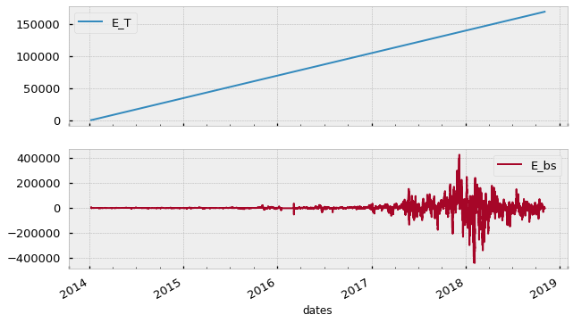

```python
df0[['E_T','E_bs']].plot(subplots=True, figsize=(10,6));
```

```python
display(df0.describe()/1000)
```

|  | bs | E_T | E_bs | absMul | absTheta |
| --- | --- | --- | --- | --- | --- |
| count | 158.277000 | 169.064000 | 169.064000 | 1.690640e+02 | 158.277000 |
| mean | 1.344898 | 84.362779 | 1.130192 | 2.026670e+06 | 85480.351314 |
| std | 426.272960 | 48.804236 | 36.469932 | 4.710617e+06 | 129074.212941 |
| min | -9925.003456 | 0.000000 | -438.576894 | 0.000000e+00 | 0.089642 |
| 25% | -17.501567 | 42.096750 | -1.756159 | 2.080504e+04 | 8848.976036 |
| 50% | 0.190054 | 84.362500 | -0.096050 | 1.570671e+05 | 15271.168754 |
| 75% | 22.824625 | 126.628250 | 2.927147 | 1.604495e+06 | 132559.419790 |
| max | 12828.471880 | 168.894000 | 424.571955 | 6.263580e+07 | 557340.856927 |

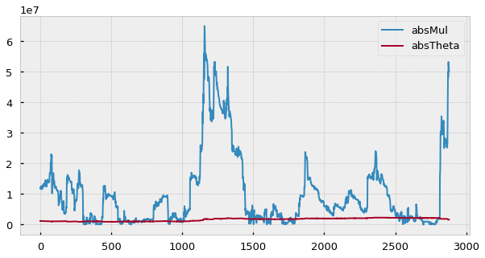

```python
(df0.loc['2014-06',['absMul','absTheta']]
 .reset_index(drop=True)
 .plot(figsize=(10,5)))
```

```python
def test_t_abs(absTheta,t,E_bs):
    """
    Bool function to test inequality
    *row is assumed to come from df.itertuples()
    -absTheta: float(), row.absTheta
    -t: pd.Timestamp()
    -E_bs: float(), row.E_bs
    """
    return (absTheta >= t*E_bs)

def agg_imbalance_bars(df):
    """
    Implements the accumulation logic
    """
    start = df.index[0]
    bars = []
    for row in df.itertuples():
        t_abs = row.absTheta
        rowIdx = row.Index
        E_bs = row.E_bs

        t = df.loc[start:rowIdx].shape[0]
        if t<1: t=1 # if t lt 1 set equal to 1
        if test_t_abs(t_abs,t,E_bs):
            bars.append((start,rowIdx,t))
            start = rowIdx
    return bars
```

```python
bars = agg_imbalance_bars(df0)
test_imb_bars = (pd.DataFrame(bars,columns=['start','stop','Ts'])
                 .drop_duplicates())
test_imb_bars.head()
```

|  | start | stop | Ts |
| --- | --- | --- | --- |
| 0 | 2014-01-08 11:30:00 | 2014-01-08 11:30:00 | 1 |
| 1 | 2014-01-08 11:30:00 | 2014-01-08 11:45:00 | 2 |
| 2 | 2014-01-08 11:45:00 | 2014-01-08 12:00:00 | 2 |
| 3 | 2014-01-08 12:00:00 | 2014-01-08 12:15:00 | 2 |
| 4 | 2014-01-08 12:15:00 | 2014-01-08 12:30:00 | 2 |

```python
test_imb_bars.Ts.describe().round()
```

```
count    158271.0
mean          2.0
std          11.0
min           1.0
25%           2.0
50%           2.0
75%           2.0
max        4472.0
Name: Ts, dtype: float64
```

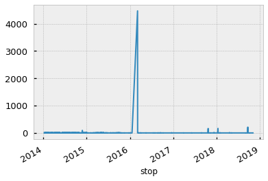

```python
test_imb_bars.set_index('stop')['Ts'].plot()
```

```python
dvImbBars = df_EOD.price.loc[test_imb_bars.stop].drop_duplicates()
dvImbBars.head()
```

```
dates
2014-01-08 11:30:00    625.757599
2014-01-08 11:45:00    628.710288
2014-01-08 12:00:00    623.550000
2014-01-08 12:15:00    631.936829
2014-01-08 12:30:00    634.640600
Name: price, dtype: float64
```

```python
dvBar = dv_bar_df.price
dvBar.head()
```

```
dates
2014-01-08 11:30:00    625.757599
2014-01-08 11:45:00    628.710288
2014-01-08 12:00:00    623.550000
2014-01-08 12:15:00    631.936829
2014-01-08 12:30:00    634.640600
Name: price, dtype: float64
```

```python
dr = returns(dv_bar_df.price)
drImb = returns(dvImbBars)
```

```python
bar_types = ['dvBar','dvImb']
bar_rets = [dr, drImb]

get_test_stats(bar_types,bar_rets,pd.Series.autocorr)
```

|  | sample_size | autocorr_stat |
| --- | --- | --- |
| dvBar | 162945.0 | 0.169558 |
| dvImb | 157908.0 | 0.165819 |

[figure not shown]

```python
plot_autocorr(bar_types,bar_returns)
```

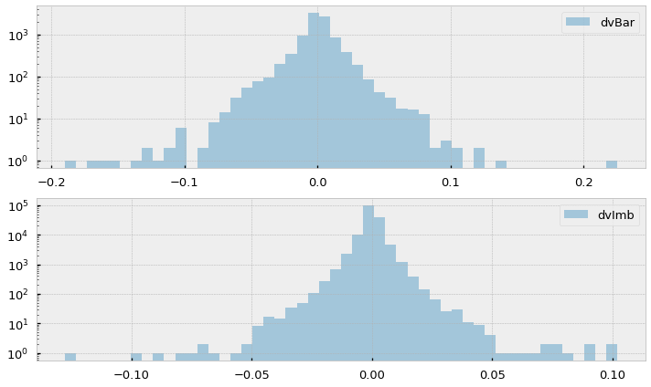

```python
plot_hist(bar_types,bar_returns)
```

```python
jbs = get_test_stats(bar_types,bar_returns,jb).sort_values('jb_stat')
shaps = (get_test_stats(bar_types,bar_returns,shapiro)
         .sort_values('shapiro_stat')[::-1])

display(jbs,shaps)
```

[output not shown]

[output not shown]